# Act Report

Act Report communicates the insights and displays the visualizations produced from wrangled data while doing the project (saved as 'wrangle_act.ipynb').

Final dataset after wrangiling used for analysis and visualization contains 1450 rows and 13 columns. The most important columns for analysis are: `retweet_count`, `favorite_count`, `rating`, `breed_prediction` and `name`.

## Twitter users' favorite and the most retweeted dog breeds

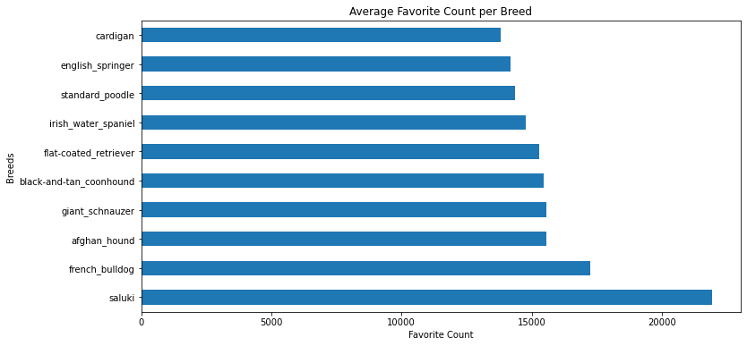

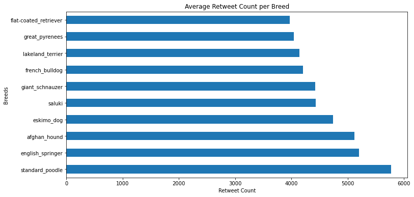

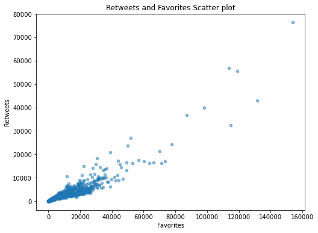

As we can see, there is a strong positive correlation between favorites and retweets by users. It's not suprising as users often retweet and like the same photos.

##### Top 3 favorite dogs are:

- Saluki
- French Bulldog
- Afghan Hound

##### Top 3 retweeted dogs are:

- Standard Poodle
- English Springer
- Afghan Hound

## WeRateDog's favorite breeds

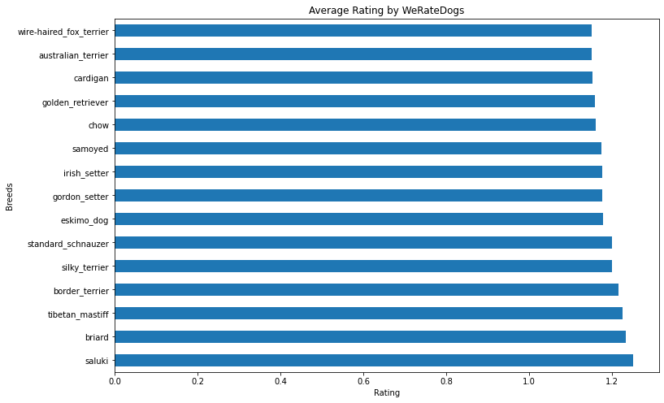

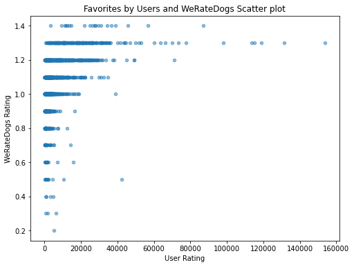

Here we also can see positive correlation between favorites by users and by WeRateDogs but it's not as strong as the one between favorites and retwets by users.

##### According to WeRateDogs, the most adorable and highly rated dog breed are:

- Saluki
- Briard
- Tibetian Mastiff
- Border Terrier
- Silky Terrier

An interesting fact is that the most favorite dog is the same for both users and WeRateDogs. It's Saluki.

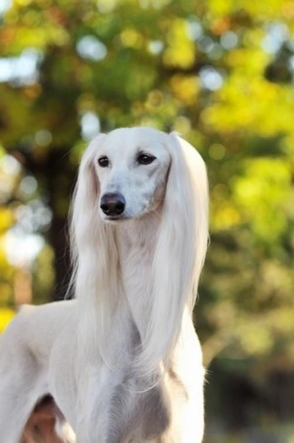

## Popular dog names

As we can see below, people like to call their dogs:

- Cooper
- Charlie
- Oliver
- Penny
- Lucy
- Tucker

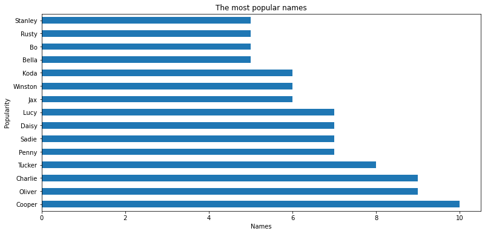